# CNN Class Exercise

by Maxwell Ernst 03/07/2023

## Exercise Description:

Choose an image classification problem that is well-suited to be solved using transfer learning. Choose a suitable pretrained model, re-use the weights of the convolutional layers, and train the dense layers using a series of input images of your own choice.

Hand in your Jupyter notebook which also functions as a research report. You describe the context of the problem at hand, the methods, the results, and your conclusion. To show progress of training, you should create plots of accuracy and loss versus epoch number. For evaluation, you should construct a confusion matrix and discuss your findings. In addition, you can show some example test images that are classified right and some that are classified wrong. This gives an idea of what your network is capable of (in addition to your confusion matrix and other evaluation metrics).

## Approach :

Use CNN to classify images, using a pre-trained model, for transfer learning. Fine-tuning to increase the accuracy.

# Libraries

```python
import matplotlib.pyplot as plt
import numpy as np
import os
import tensorflow as tf
```

# Data

The data set used contains thousands of images of cats and dogs. I will be following this tutorial to get started. https://www.tensorflow.org/tutorials/images/transfer_learning

```python
_URL = 'https://storage.googleapis.com/mledu-datasets/cats_and_dogs_filtered.zip'
path_to_zip = tf.keras.utils.get_file('cats_and_dogs.zip', origin=_URL, extract=True)
PATH = os.path.join(os.path.dirname(path_to_zip), 'cats_and_dogs_filtered')

train_dir = os.path.join(PATH, 'train')
validation_dir = os.path.join(PATH, 'validation')

BATCH_SIZE = 32
IMG_SIZE = (160, 160)

train_dataset = tf.keras.utils.image_dataset_from_directory(train_dir,
                                                            shuffle=True,
                                                            batch_size=BATCH_SIZE,
                                                            image_size=IMG_SIZE)
```

```
Found 2000 files belonging to 2 classes.
```

```python
validation_dataset = tf.keras.utils.image_dataset_from_directory(validation_dir,
                                                                 shuffle=True,
                                                                 batch_size=BATCH_SIZE,
                                                                 image_size=IMG_SIZE)
```

```
Found 1000 files belonging to 2 classes.
```

[figure not shown]

```python
# Showing first 9 images
class_names = train_dataset.class_names

plt.figure(figsize=(10, 10))
for images, labels in train_dataset.take(1):
  for i in range(9):
    ax = plt.subplot(3, 3, i + 1)
    plt.imshow(images[i].numpy().astype("uint8"))
    plt.title(class_names[labels[i]])
    plt.axis("off")
```

```python
images.shape
```

```
TensorShape([32, 160, 160, 3])
```

# Data handling

Creating a test data set for the model

```python
val_batches = tf.data.experimental.cardinality(validation_dataset)
test_dataset = validation_dataset.take(val_batches // 5)
validation_dataset = validation_dataset.skip(val_batches // 5)
```

```python
print('Number of validation batches: %d' % tf.data.experimental.cardinality(validation_dataset))
print('Number of test batches: %d' % tf.data.experimental.cardinality(test_dataset))
```

```
Number of validation batches: 26
Number of test batches: 6
```

## Using data Augmentation

Since the data set is not the largest, it is a good idea to introduce some artificial noise to the data set.By applying random transformations to the data set. This helps expose the model to different ascpects of the training data.

```python
AUTOTUNE = tf.data.AUTOTUNE

train_dataset = train_dataset.prefetch(buffer_size=AUTOTUNE)
validation_dataset = validation_dataset.prefetch(buffer_size=AUTOTUNE)
test_dataset = test_dataset.prefetch(buffer_size=AUTOTUNE)
```

```python
data_augmentation = tf.keras.Sequential([
  tf.keras.layers.RandomFlip('horizontal'),
  tf.keras.layers.RandomRotation(0.2),
])
```

Lets see the results of the asugmentation on one image.

[output not shown]

[output cut: 17 more lines]

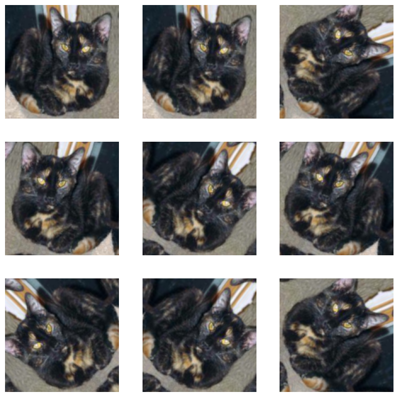

```python
for image, _ in train_dataset.take(1):
  plt.figure(figsize=(10, 10))
  first_image = image[0]
  for i in range(9):
    ax = plt.subplot(3, 3, i + 1)
    augmented_image = data_augmentation(tf.expand_dims(first_image, 0))
    plt.imshow(augmented_image[0] / 255)
    plt.axis('off')
```

## Rescaling images

The base model can only take values between -1,1 therefore we need to convert the value of the pixels from 255 to between -1 and 1.

```python
preprocess_input = tf.keras.applications.mobilenet_v2.preprocess_input
```

```python
rescale = tf.keras.layers.Rescaling(1./127.5, offset=-1)
```

The Rescaling layer takes two arguments: scale and offset. In this case, scale is set to 1./127.5, which means that the input tensor will be multiplied by this scale factor. The purpose of this scaling is to make the input values fall in the range of [-1, 1], which is commonly used in deep learning models to help with numerical stability and convergence. The choice of 127.5 in the denominator is because this is half of the maximum pixel value for an image in the RGB color space, which is 255.

# Creating the base model that will be pre-trained.

The model chosen is the MobileNetV2 model developed by google. To instantiate a MobileNet V2 model pre-loaded with weights trained on ImageNet for feature extraction, you can specify the include_top=False argument. This loads the network without the classification layers at the top, which is perfect for extracting features.

MobileNet V2 is a convolutional neural network architecture designed for efficient mobile and embedded vision applications. It was developed by Google researchers and is an improvement over the original MobileNet model.

```python
IMG_SHAPE = IMG_SIZE + (3,)
base_model = tf.keras.applications.MobileNetV2(input_shape=IMG_SHAPE,
                                               include_top=False,
                                               weights='imagenet')
```

The feature extractor converts the images from 160x160x3 to 5x5x1280 block of features.

```python
image_batch, label_batch = next(iter(train_dataset))
feature_batch = base_model(image_batch)
print(feature_batch.shape)
```

```
(32, 5, 5, 1280)
```

## Feature Extraction

Freezing the convlutional base before compiling and training the model to prevent the weights from being updated. When a pre-trained model is used as a starting point, the weights of the convolutional layers are already trained on a large dataset, often millions of images. These weights are generally very effective feature extractors for a wide range of image-related tasks.

By freezing the convolutional layers, we are essentially telling the model to keep these pre-trained weights fixed and not update them during training. This means that the convolutional base will act as a fixed feature extractor for the new task, and only the weights of the top layers of the model will be updated during training.

```python
base_model.trainable = False
```

```python
base_model.summary()
```

[output not shown]

[output cut: 365 more lines]

```

 block_16_project_BN (BatchNorm  (None, 5, 5, 320)   1280        ['block_16_project[0][0]']
 alization)

 Conv_1 (Conv2D)                (None, 5, 5, 1280)   409600      ['block_16_project_BN[0][0]']

 Conv_1_bn (BatchNormalization)  (None, 5, 5, 1280)  5120        ['Conv_1[0][0]']

 out_relu (ReLU)                (None, 5, 5, 1280)   0           ['Conv_1_bn[0][0]']

==================================================================================================
Total params: 2,257,984
Trainable params: 0
Non-trainable params: 2,257,984
__________________________________________________________________________________________________
```

Adding a classification head.

using a tf.keras.layers.GlobalAveragePooling2D layer to convert the features to a single 1280-element vector per image.

```python
global_average_layer = tf.keras.layers.GlobalAveragePooling2D()
feature_batch_average = global_average_layer(feature_batch)
print(feature_batch_average.shape)
```

```
(32, 1280)
```

Apply a tf.keras.layers.Dense layer to convert these features into a single prediction per image.

```python
prediction_layer = tf.keras.layers.Dense(1)
prediction_batch = prediction_layer(feature_batch_average)
print(prediction_batch.shape)
```

```
(32, 1)
```

### Building the model

with training = False and the BatchNormalization layer is used

```python
inputs = tf.keras.Input(shape=(160, 160, 3))
x = data_augmentation(inputs)
x = preprocess_input(x)
x = base_model(x, training=False)
x = global_average_layer(x)
x = tf.keras.layers.Dropout(0.2)(x)
outputs = prediction_layer(x)
model = tf.keras.Model(inputs, outputs)
```

[output not shown]

### Compiling the model

```python
base_learning_rate = 0.0001
model.compile(optimizer=tf.keras.optimizers.Adam(learning_rate=base_learning_rate),
              loss=tf.keras.losses.BinaryCrossentropy(from_logits=True),
              metrics=['accuracy'])
```

```python
model.summary()
```

[output not shown]

From the summary above it shows that there are over 2,2 million forzen paramater frozen in the MobileNetV2 model. 1,281 are in the dense layer.

```python
len(model.trainable_variables)
```

```
2
```

# Training the model

Training for 10 Epochs.

```python
initial_epochs = 10

loss0, accuracy0 = model.evaluate(validation_dataset)
```

```python
print("initial loss: {:.2f}".format(loss0))
print("initial accuracy: {:.2f}".format(accuracy0))
```

```
initial loss: 0.81
initial accuracy: 0.50
```

```python
history = model.fit(train_dataset,
                    epochs=initial_epochs,
                    validation_data=validation_dataset)
```

[output not shown]

#### Plotting Accuracy and Loss versus Epoch number for the model

As the epochs increase to around 9 the model accuracy reaches above 0.9 and flattens out as show below.

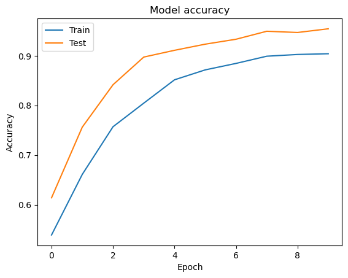

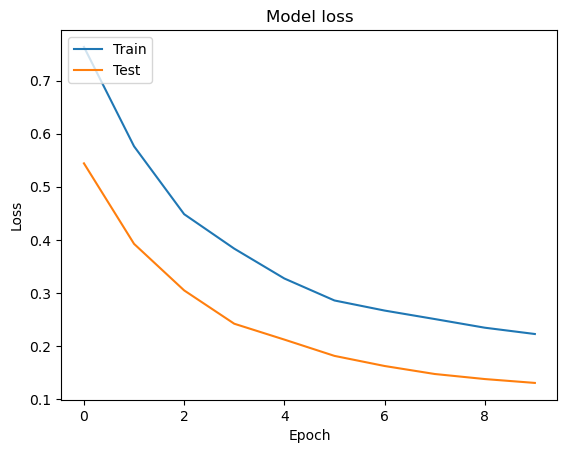

```python
# Plot the accuracy and loss versus epoch number
plt.plot(history.history['accuracy'])
plt.plot(history.history['val_accuracy'])
plt.title('Model accuracy')
plt.ylabel('Accuracy')
plt.xlabel('Epoch')
plt.legend(['Train', 'Test'], loc='upper left')
plt.show()

plt.plot(history.history['loss'])
plt.plot(history.history['val_loss'])
plt.title('Model loss')
plt.ylabel('Loss')
plt.xlabel('Epoch')
plt.legend(['Train', 'Test'], loc='upper left')
plt.show()
```

The loss has the same effect but in a negative curve. The lower the loss, the higher the accuracy.

## Fine Tuning

In the feature selection we are only training a few layers on top of the MobilveV2 base model. The weights are not updated during the training process.

To train or fine tune the weights of the top layers of the pre-trained model alonsgide the classifier that was added can increase the performance of the model.

## Un-freeze the top layers of the model.

To unfreeze the base_model and set the bottoms layers to untrainable, the model will need to be recompiled, and then resume trianing.

```python
base_model.trainable = True
```

```python
print("Number of layers in the base model: ", len(base_model.layers))
fine_tune_at = 100
for layer in base_model.layers[:fine_tune_at]:
  layer.trainable = False
```

```
Number of layers in the base model:  154
```

# Continuing the training

```python
fine_tune_epochs = 10
total_epochs =  initial_epochs + fine_tune_epochs

history_fine = model.fit(train_dataset,
                         epochs=total_epochs,
                         initial_epoch=history.epoch[-1],
                         validation_data=validation_dataset)
```

The results seem to reach over 0.94 % accuracy. This is quite a strong accuracy. The validation loss shows how well the model is able to generalise to new data. A low validation loss means that the model is performing well on new data.

### Plotting learning curves

```python
acc += history_fine.history['accuracy']
val_acc += history_fine.history['val_accuracy']

loss += history_fine.history['loss']
val_loss += history_fine.history['val_loss']
```

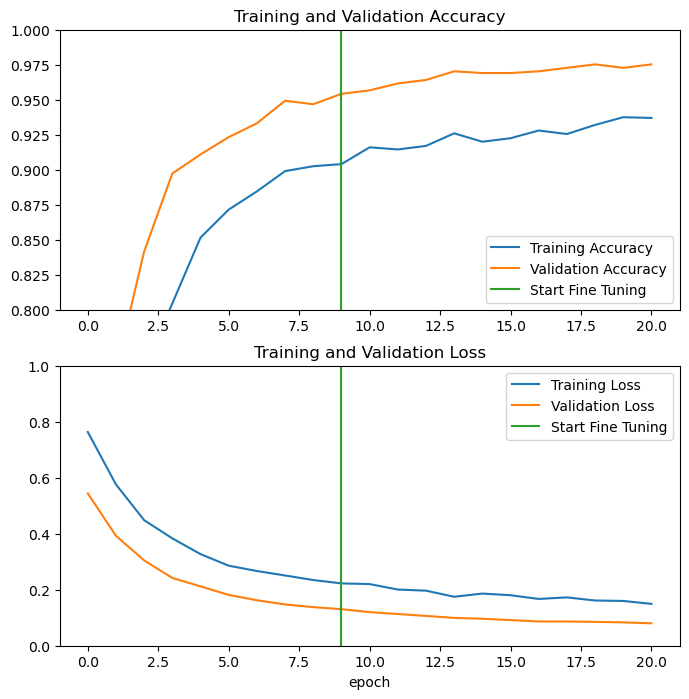

```python
plt.figure(figsize=(8, 8))
plt.subplot(2, 1, 1)
plt.plot(acc, label='Training Accuracy')
plt.plot(val_acc, label='Validation Accuracy')
plt.ylim([0.8, 1])
plt.plot([initial_epochs-1,initial_epochs-1],
          plt.ylim(), label='Start Fine Tuning')
plt.legend(loc='lower right')
plt.title('Training and Validation Accuracy')

plt.subplot(2, 1, 2)
plt.plot(loss, label='Training Loss')
plt.plot(val_loss, label='Validation Loss')
plt.ylim([0, 1.0])
plt.plot([initial_epochs-1,initial_epochs-1],
         plt.ylim(), label='Start Fine Tuning')
plt.legend(loc='upper right')
plt.title('Training and Validation Loss')
plt.xlabel('epoch')
plt.show()
```

## Evaluation

Lets verify the performance of the model.

```python
loss, accuracy = model.evaluate(test_dataset)
print('Test accuracy :', accuracy)
```

```
Test accuracy : 0.9791666865348816
```

The test accruacy seems to be much higher now that the model has been succefully tuned.

#### Confusion Matrix

A confusion matrix will be used to evaluate the performance of the model.

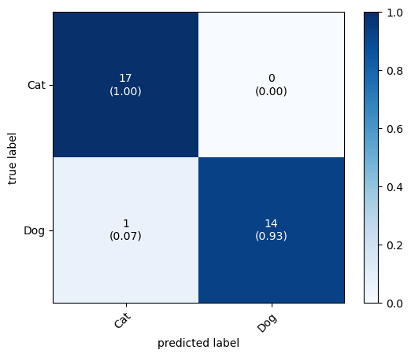

```python
import numpy as np
from sklearn.metrics import confusion_matrix
import matplotlib.pyplot as plt
from mlxtend.plotting import plot_confusion_matrix

# batch of images from the test set
image_batch, label_batch = test_dataset.as_numpy_iterator().next()
predictions = model.predict_on_batch(image_batch).flatten()

# sigmoid since our model returns logits
predictions = tf.nn.sigmoid(predictions)
predictions = tf.where(predictions < 0.5, 0, 1)

# confusion matrix
cm = confusion_matrix(label_batch, predictions)
class_names = ['Cat', 'Dog'] # Replace with your own class names

# Plot confusion matrix
fig, ax = plot_confusion_matrix(conf_mat=cm,
                                colorbar=True,
                                show_absolute=True,
                                show_normed=True,
                                class_names=class_names)

plt.show()
```

## Predictions

Ploting the predictions label with the image.

```
Predictions:
 [0 0 0 1 0 1 0 1 0 0 1 0 0 1 0 1 0 1 1 0 1 1 1 0 1 1 1 0 0 0 1 0]
Labels:
 [1 0 0 1 0 1 0 1 0 0 1 0 0 1 0 1 0 1 1 0 1 1 1 0 1 1 0 0 0 0 1 0]
```

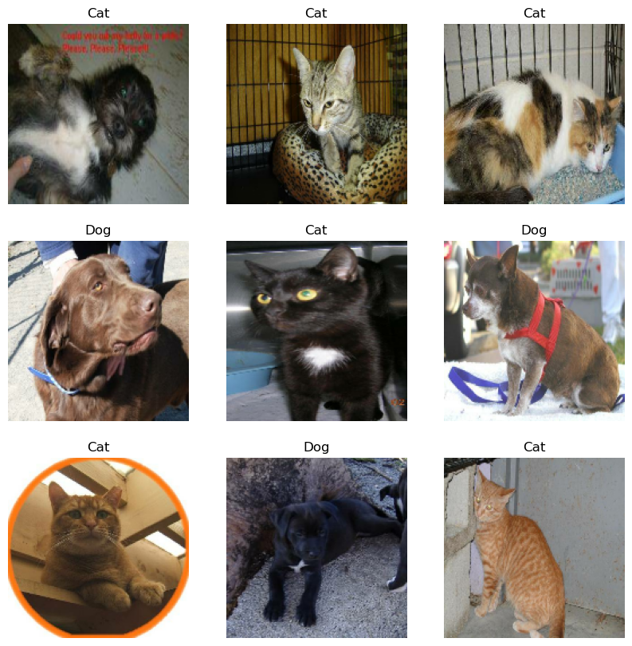

```python
# Retrieve a batch of images from the test set
image_batch, label_batch = test_dataset.as_numpy_iterator().next()
predictions = model.predict_on_batch(image_batch).flatten()

# Apply a sigmoid since our model returns logits
predictions = tf.nn.sigmoid(predictions)
predictions = tf.where(predictions < 0.5, 0, 1)

print('Predictions:\n', predictions.numpy())
print('Labels:\n', label_batch)

plt.figure(figsize=(10, 10))
for i in range(9):
  ax = plt.subplot(3, 3, i + 1)
  plt.imshow(image_batch[i].astype("uint8"))
  plt.title(class_names[predictions[i]])
  plt.axis("off")
```

The model seems to be working well and is able to predict if the image is a dog or cat. Sometimes there can be an error in the prediction but the model has quite a high accuracy score.

# Conlusion

In this CNN exercise I ws able to apply CNN to a dogs and cats image dataset using transfer learning. The exercise proved to be a good practice. I can see the potential in the transfer learning process.

### Summary

Using a pretrained model:

- Using a pre-trained model from a larger dataet in the same domain is common with small datasets.
- The pre-trained model is frozen and only the weights are updated during training.

Fine tuning:

- Repurposing the top-level layers to the new data set
- Tuning weights for the model to learn high-level features for the new data set. (recommended for larger datasets)

Evaluation:

- Using a confusion matrix to evaluate the performance of the pre-trained model on the new data set.
- PLotting the accuracy and loss of the pre-trained model on the new data set.